# clase_02

# [Broadcasting](https://numpy.org/doc/stable/user/basics.broadcasting.html)

En primer lugar una aclaracion: En Numpy, el operador '*' realiza la multiplicacion elemento a elemento entre arrays. Para realizar el producto matricial se utiliza el operador '@', aunque comunmente cuando es necesario aplicar esta operacion se emplean funciones de Numpy pensadas para eso, que lo realizan de manera mas eficiente.

El termino **broadcasting** describe la manera en la que NumPy maneja los arrays con diferentes dimensiones durante operaciones aritmeticas. Sujeto a ciertas restricciones, en general se busca adaptar el array mas chico al array mas grande de manera de conseguir que ambos tengan dimensiones compatibles.

Cuando queremos operar con dos arrays, NumPy compara las dimensiones para ver si son compatibles, de derecha a izquierda. Dos dimensiones son compatibles cuando

- Son iguales entre si
- Una de ellas vale 1

En el segundo caso, la operación entre arrays se realiza igualmente, aunque no coincidan en una de sus dimensiones. Mediante el broadcasting, el array más pequeño se replica para poder operar con el más grande. El término alude a cómo Numpy realiza las operaciones con arrays. En español, se podría traducir como 'expansión' ya que describe lo que sucede al operar entre arrays de distintos tamaños, donde **el array más pequeño se expande a lo largo del array más grande** para poder realizar la operación. Esto se hace automáticamente y puede ser aprovechado para realizar operaciones en pocos pasos, sin necesidad de aplicar iteraciones.

Si no se cumple ninguna de las dos posibilidades de compatibilidad entre dimensiones, vamos a tener un error del tipo *ValueError: operands could not be broadcast together*.

Los arrays no tienen que tener necesariamente el mismo número de dimensiones, ya que dimensiones de tamaño 1 se pueden *estirar* o *copiar* para hacer coincidir el numero de dimensiones. Las dimensiones del array resultante es igual al valor que no es igual a 1 en cada eje. Par entenderlo mejor, veamoslo en codigo!

```python
# partimos de estos dos vectores
t = np.array([1,2,3,4], dtype = np.int8)
u = np.array([0,5,10], dtype = np.int8)


print(f'Shape de t: {t.shape}\nShape de u: {u.shape}')
```

```
Shape de t: (4,)
Shape de u: (3,)
```

De acuerdo como defina el vector, lo puedo tomar como fila o columna. En general, cuando vamos a trabajar en forma matricial nos interesa considerar ambas dimensiones. De todas maneras, cualquier dimension de valor 1 se puede comprimir. Usualmente se usa el termino "shrink" para esta tarea. Veamos como podemos sumar o restar dimensiones, que alteran el formato pero no agregan informacion al array:

```python
#Como vector columna
t = t.reshape(4,1)
u = u.reshape(3,1)
print(f'Shape de t: {t.shape}\nShape de u: {u.shape}')
```

```
Shape de t: (4, 1)
Shape de u: (3, 1)
```

```python
#Como vector fila
t = t.reshape(1,4)
u = u.reshape(1,3)
print(f'Shape de t: {t.shape}\nShape de u: {u.shape}')
```

```
Shape de t: (1, 4)
Shape de u: (1, 3)
```

```python
#Agregando dimensiones vacias
t = t.reshape(1,4,1)
u = u.reshape(1,3,1)
print(f'Shape de t: {t.shape}\nShape de u: {u.shape}')
t = t.reshape(1,1,1,4,1)
u = u.reshape(1,1,1,3,1)
print(f'Shape de t: {t.shape}\nShape de u: {u.shape}')
```

```
Shape de t: (1, 4, 1)
Shape de u: (1, 3, 1)
Shape de t: (1, 1, 1, 4, 1)
Shape de u: (1, 1, 1, 3, 1)
```

```python
#Muy util: sumar una dimension sin depender de la actual
t = t.reshape(1,-1)
u = u.reshape(1,-1)
print(f'Shape de t: {t.shape}\nShape de u: {u.shape}')
```

```
Shape de t: (1, 4)
Shape de u: (1, 3)
```

[figure not shown]

```python
t + u
```

```
---------------------------------------------------------------------------
ValueError                                Traceback (most recent call last)
c:\Users\abelm\Documents\signals_and_systems\practica_2\clase_02.ipynb Celda 61 in <cell line: 1>()
----> <a href='vscode-notebook-cell:/c%3A/Users/abelm/Documents/signals_and_systems/practica_2/clase_02.ipynb#Y114sZmlsZQ%3D%3D?line=0'>1</a> t + u

ValueError: operands could not be broadcast together with shapes (1,4) (1,3)
```

```python
# cambiamos la forma de 'u' para poder operar
t = t.reshape(1,4)
u = u.reshape(3,1)
print(u)
```

```
[[ 0]
 [ 5]
 [10]]
```

[figure not shown]

Con estas dimensiones, ahora si cumplimos las compatibilidades de ambas dimensiones de modo que podemos operar. El array **t** hace broadcasting (x3) en la primer dimension para igualar a la primer dimension de **u**, y el array **u** hace broadcasting (x4) en la segunda dimension para igualar a la dimension de **t**. Se puede ver cual va a ser la dimension del resultado, acorde a lo establecido por el broadcasting (3X4)

[figure not shown]

```python
t + u
```

```
array([[ 1,  2,  3,  4],
       [ 6,  7,  8,  9],
       [11, 12, 13, 14]], dtype=int8)
```

Lo anterior es equivalente a realizar la siguiente operación entre arrays de iguales dimensiones:

```python
t2 = np.array([[1,2,3,4],[1,2,3,4],[1,2,3,4]], dtype=np.int8)
u2 = np.array([[0,0,0,0],[5,5,5,5],[10,10,10,10]], dtype=np.int8)
```

```python
t2 + u2
```

```
array([[ 1,  2,  3,  4],
       [ 6,  7,  8,  9],
       [11, 12, 13, 14]], dtype=int8)
```

## Otras formas de crear arrays

Numpy provee funciones para crear ciertos tipos de arrays de común uso. Veamos algunos casos:

```python
# creamos un array de unos
array_unos = np.ones((2,6), dtype = np.uint8)

# creamos un array de ceros
array_ceros = np.zeros((3,3), dtype = np.uint8)

# creamos una secuencia creciente de números
sec_nros = np.arange(10, dtype = np.uint8)

# otra secuencia de números
otra_sec_nros = np.linspace(0,5,5, dtype=np.float16)

print(array_unos, "\n")
print(array_ceros, "\n")
print(sec_nros, "\n")
print(otra_sec_nros, "\n")
```

```
[[1 1 1 1 1 1]
 [1 1 1 1 1 1]]

[[0 0 0]
 [0 0 0]
 [0 0 0]]

[0 1 2 3 4 5 6 7 8 9]

[0.   1.25 2.5  3.75 5.  ]
```

Veamos algunas formas de crear secuencias aleatorias:

```python
# randint = enteros aleatorios - se especifica el rango de valores
rand_sec = np.random.randint(-100, 100, 8, dtype=np.int8)
print(rand_sec)
```

```
[ 20  45 -17 -97 -72  -5  97 -85]
```

```python
# rand = array con valores aleatorios entre 0 y 1 - se especifican las dimensiones y
# longitud del array
rand_sec = np.random.rand(2,3)
print(rand_sec)
```

```
[[0.62567807 0.07716976 0.03787468]
 [0.92917114 0.81863841 0.41814009]]
```

```python
# randn
rand_sec = np.random.randn(5)
print(rand_sec)
```

```
[ 1.59909949 -2.16674163  0.07227987  0.1805796   0.32801598]
```

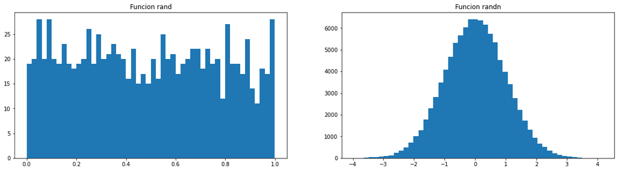

```python
rand = np.random.rand(1000)
randn = np.random.randn(100000)
fig, ax = plt.subplots(1, 2, figsize=(20,5))
ax[0].hist(rand, bins=50)
ax[0].set_title('Funcion rand')
ax[1].hist(randn, bins=50)
ax[1].set_title('Funcion randn')
plt.show()
```

## Aplicando funciones matematicas

Numpy dispone de varias funciones matemáticas para aplicar sobre un simple escalar o sobre un array. La lista completa de funciones matemáticas que provee Numpy puede verse haciendo [clic acá](https://docs.scipy.org/doc/numpy/reference/routines.math.html#trigonometric-functions).

Veamos un ejemplo:

```python
# Primero creo un vector temporal
t = np.linspace(0,1,16000) # Desde 0 hasta 1, genero 16000 puntos

# funciones seno y coseno
f_seno = np.sin(2*np.pi*1*t) #argumento --> 2 * pi * Frecuencia * tiempo
f_coseno = np.cos(2*np.pi*1*t)
```

Para una frecuencia de 1 Hz, sabemos que el período deberia ser de 1 segundo

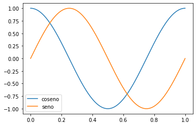

```python
plt.plot(t, f_coseno, label='coseno')
plt.plot(t, f_seno, label='seno')
plt.legend()
plt.show()
```

Entonces, podemos crear arrays para representar funciones matemáticas conocidas. Primero creamos un array para definir una serie de puntos en el dominio de la función y luego aplicamos la función sobre estos puntos.

## Funciones definidas por el usuario

[figure not shown]

Una función, es la forma de **agrupar expresiones y sentencias** que realicen determinadas acciones, pero que éstas, solo **se ejecuten cuando son llamadas**. Es decir, que al colocar un algoritmo dentro de una función y se corre el archivo, el algoritmo no será ejecutado si no se ha hecho una referencia a la función que lo contiene.

En definitiva lo más importante para programar, y no solo en Python, es saber organizar el código en piezas más pequeñas que hagan tareas independientes y combinarlas entre sí. Las funciones son el primer nivel de organización del código: reciben unas entradas, las procesan y devuelven unas salidas.

### Definicion de funciones

La palabra reservada `def` se usa para **definir funciones**. Debe seguirle el nombre de la función y la **lista de argumentos entre paréntesis**. Las sentencias que forman el cuerpo de la función empiezan en la línea siguiente, y deben estar con sangría. **La primer sentencia** del cuerpo de la función puede ser opcionalmente una cadena de texto literal (utilizar `"""`, en lugar de `#`); esta es la cadena de texto de documentación de la función, o **docstring**. Es una buena práctica, no solo documentar las funciones, sino hacerlo con un estilo único y estandarizado. Una referencia respaldada en el ecosistema científico es el estilo de documentación de [`NumPy`](https://numpydoc.readthedocs.io/en/latest/format.html#docstring-standard)

[figure not shown]

Lo vemos con un ejemplo concreto. Supongamos que estoy trabajando con datos de temperatura, y necesito una funcion que reciba un valor de temperatura expresado en Farenheit y lo convierta en Celsius. Esta conversion se da segun la siguiente expresion: \begin{equation} X_{Celsius} = (X_{Farenheit} - 32) * \frac{5}{9} \end{equation}

Entonces veamos como definimos esta funcion:

```python
def farenheit_to_celsius(x_farenheit):
    """
    Esta funcion recibe un valor de temperatura expresado
    en Farenheit, y devuelve su equivalente expresado en
    Celsius.

    """
    # para saber cuando se ejecuta la funcion, agrego un print
    print('La funcion comenzo a ejecutarse...')

    # cambio de escala
    x_celsius = (x_farenheit - 32) * (5/9)

    # retorno del resultado
    return x_celsius
```

Como vemos, al ejecutar la celda anterior estamos **definiendo** la funcion. Es decir, ahora el interprete sabe de la existencia de dicha función, y de ahora en mas la puede utilizar. Pasemos entonces a **ejecutar** la funcion

```python
x_far = 33.5
x_cel = farenheit_to_celsius(x_far)

print(f"{x_far:.2f}° Farenheit son equivalentes a {x_cel:.2f}° Celsius")
```

```
La funcion comenzo a ejecutarse...
33.50° Farenheit son equivalentes a 0.83° Celsius
```

```python
farenheit_to_celsius(x_far)
```

```
La funcion comenzo a ejecutarse...
```

```
0.8333333333333334
```

El retorno de la funcion, al igual que los parametros de entrada, son opcionales. Es decir, podemos definir funciones que no tengan parametros de entrada, asi como también funciones que no retornen ninguna variable. De igual manera, se suele utilizar la palabra return simplemente para finalizar la función.

```python
def saludar():
    print('Hola como va bla bla bla')
```

```python
saludar()
```

```
Hola como va bla bla bla
```

### Scope

Es importante resaltar que **las variables que se crean dentro de las funciones no son accesibles una vez que termina la ejecución de la función**. En cambio, la función si que puede acceder a cosas que se han definido fuera de ella. No obstantes, esto último no constituye una buena práctica de cara a la reproducibilidad, mantenibilidad y testeo de la función.

```python
# veamos un ejemplo
def sumar_cosas(a):
    c = 3
    salida = a + b + c
    return salida
# Ojo! Para borrar las variables definidas tenemos que reiniciar el kernel (shortcut 00)
```

### Argumentos

También es posible definir funciones con un número variable de argumentos. Hay tres formas que pueden ser combinadas:

- Argumentos con valores por omisión.
- Palabras claves como argumentos.
- Listas de argumentos arbitrarios.

#### Argumentos con valores por omision

La forma más útil es especificar un valor por omisión para uno o más argumentos. Esto crea una función que puede ser llamada con menos argumentos que los que permite. Por ejemplo:

```python
def pedir_confirmacion(prompt, reintentos=4, recordatorio="Por favor, intente nuevamente!"):
    while True:
        ok = input(prompt)
        if ok in ("s", "S", "si", "Si", "SI", "sI"):  # contemplando todos los casos, "in" palabra resevada para probar si una secuencia contiene o no un determinado valor.
            return True
        if ok in ("n", "N", "no", "No", "NO", "nO"):  # contemplando todos los casos
            return False
        reintentos -= 1
        if reintentos < 0:
            raise ValueError("respuesta de usuario inválida")
        print (recordatorio)
```

```python
# pasando solo el argumento obligatorio
pedir_confirmacion("¿Realmente queres salir?")
```

```
¿Realmente queres salir?asd
Por favor, intente nuevamente!
¿Realmente queres salir?asd
Por favor, intente nuevamente!
¿Realmente queres salir?s
```

```
True
```

```python
# y si no paso un parametro obligatorio?
pedir_confirmacion(reintentos=4, recordatorio='Proba de nuevo!')
```

```
---------------------------------------------------------------------------
TypeError                                 Traceback (most recent call last)
<ipython-input-8-4d194b76a55e> in <module>
      1 # y si no paso un parametro obligatorio?
----> 2 pedir_confirmacion(reintentos=4, recordatorio='Proba de nuevo!')

TypeError: pedir_confirmacion() missing 1 required positional argument: 'prompt'
```

```python
# pasando uno de los argumento opcionales
pedir_confirmacion("¿Sobreescribir el archivo?", 2)
```

```
¿Sobreescribir el archivo?s
```

```
True
```

```python
# pasando todos los argumentos
pedir_confirmacion("¿Sobreescribir el archivo?", 2, "Vamos, solo si o no!")
```

```
¿Sobreescribir el archivo?s
```

```
True
```

#### Palabras claves como argumentos

Las funciones también puede ser llamadas usando argumentos con palabras claves (o argumentos nombrados) de la forma **keyword = value**. Por ejemplo, la siguiente función:

```python
def frases(objeto, accion='crepitar', respuesta='42', campeon='Ecuador'):
    print(f"-- Nunca oiste la {objeto} {accion} ")
    print(f"-- La respuesta la gran pregunta de la vida, el universo y todo, es: {respuesta}")
    print(f"-- El proximo campeon del mundo sera {campeon}!")
```

Acepta un argumento obligatorio (objeto) y tres argumentos opcionales (accion, respuesta y campeon). Esta función puede llamarse de cualquiera de las siguientes maneras:

```python
frases('ojarasca')  # 1 argumento posicional
```

```
-- Nunca oiste la ojarasca crepitar
-- La respuesta la gran pregunta de la vida, el universo y todo, es: 42
-- El proximo campeon del mundo sera Ecuador!
```

```python
frases(objeto='ojarasca')  # 1 argumento nombrado, palabra clave
```

```
-- Nunca oiste la ojarasca crepitar
-- La respuesta la gran pregunta de la vida, el universo y todo, es: 42
-- El proximo campeon del mundo sera Ecuador!
```

```python
frases(objeto = 'ojarasca', accion='caer')  # 2 argumentos nombrados
```

```
-- Nunca oiste la ojarasca caer
-- La respuesta la gran pregunta de la vida, el universo y todo, es: 42
-- El proximo campeon del mundo sera Ecuador!
```

```python
frases(accion='caer', objeto='ojarasca') # 2 argumentos nombrados, sin orden
```

```
-- Nunca oiste la ojarasca caer
-- La respuesta la gran pregunta de la vida, el universo y todo, es: 42
-- El proximo campeon del mundo sera Ecuador!
```